# feather river redd survey locations naming qc - adding names to data

2024-12-09

The goal of this markdown is to clean up the location names from Feather River redd survey data.

Summary of work that has been done so far:

- *redd_qc_2014-2023* - mainly exploratory:
  - raw data is pulled in, negative velocity values are set to NA
  - pot_depth_m >= 40 is set to NA
  - “type” is removed
  - 2023 number_redds set all to 1
  - note that 7 data entries in the raw data that had “0” in number_redds, those were set to 1
- *mapping_qc*: looks into latitude longitude and identifies issues.
  - Data file input: “data/archive/all_redd_data.csv”
- *clean_locations*: fixed latitude/longitude provided by Chris Cook, these changes address the issues found on mapping_qc.
  - Data file input: “data/archive/all_redd_data.csv”.
  - Data file output(s): “data-raw/redd_observations_clean_locations.csv” and “data/redd_observations.csv” (`location`, `survey_wk` and `file_number` removed)

### Looking into unique location names

- There are 81 unique names

```
##  [1] "upper cottonwood"              "cottonwood"
##  [3] "lower auditorium"              "moe's side channel"
##  [5] "top of auditorium"             "upper hatchery riffle"
##  [7] "upper auditorium"              "mid auditorium"
##  [9] "hatchery riffle"               "developing riffle"
## [11] "upper mcfarland"               "big riffle"
## [13] "g95 east bottom"               "g95 main"
## [15] "big hole east"                 "vance east"
## [17] "below big hole east"           "upper hour east"
## [19] "upper hour"                    "mid hour"
## [21] "keister"                       "big bar"
## [23] "lower mcfarland"               "middle auditorium"
## [25] "upper hatchery"                "hatchery"
## [27] "hatchery side channel"         "table mountain"
## [29] "g95 west side channel"         "g-95 east top"
```

[output cut: 26 more lines]

Survey location names - The following names below are survey locations names provided by Feather River team. These location names are what they have on their reports and how they categorize the locations where surveys are conducted. Redd data locations will be matched to these names

|  | ID | Location Name |
| --- | --- | --- |
| 26 | 26 | aleck |
| 14 | 14 | bedrock |
| 32 | 32 | belowbigholeeast |
| 13 | 13 | belowlowerauditorium |
| 40 | 40 | big |
| 42 | 42 | bigbar |
| 30 | 30 | bigholeeast |
| 31 | 31 | bigholewest |
| 4 | 4 | cottonwood |
| 45 | 45 | developing |
| 23 | 23 | eye |
| 24 | 24 | eyesidechannel |
| 35 | 35 | g95eastsidechannelbottom |
| 34 | 34 | g95eastsidechanneltop |
| 33 | 33 | g95westsidechannel |
| 25 | 25 | gateway |
| 39 | 39 | goose |
| 3 | 3 | hatchery |
| 10 | 10 | hatcherypipe |
| 27 | 27 | hatcherysidechannel |
| 38 | 38 | keister |
| 9 | 9 | lowerauditorium |
| 41 | 41 | lowerbig |
| 37 | 37 | lowerhour |
| 44 | 44 | lowermcfarland |
| 19 | 19 | lowerrobinson |
| 11 | 11 | lowertablemountain |
| 17 | 17 | mathews |
| 8 | 8 | middleauditorium |
| 6 | 6 | moessidechannel |
| 20 | 20 | steep |
| 21 | 21 | steepsidechannel |
| 12 | 12 | tablemountain |
| 5 | 5 | topofauditorium |
| 15 | 15 | trailerpark |
| 7 | 7 | upperauditorium |
| 2 | 2 | uppercottonwood |
| 1 | 1 | upperhatchery |
| 36 | 36 | upperhour |
| 16 | 16 | uppermathews |
| 43 | 43 | uppermcfarland |
| 18 | 18 | upperrobinson |
| 28 | 28 | vanceeast |
| 29 | 29 | vancewest |
| 22 | 22 | weir |

Identifying redd locations that do not match survey location names

```
##  [1] "moe'ssidechannel"          "upperhatcheryriffle"
##  [3] "midauditorium"             "hatcheryriffle"
##  [5] "developingriffle"          "bigriffle"
##  [7] "g95eastbottom"             "g95main"
##  [9] "upperhoureast"             "midhour"
## [11] "g-95easttop"               "g-95main"
## [13] "hour"                      "moe'sditch"
## [15] "g-95eastsidechannelbottom" "g-95westsidechannelbottom"
## [17] "weirriffle"                "steepriffle"
## [19] "lowervanceeast"            "g95easttop"
## [21] "greatwestern"              "topofhatchery"
## [23] "lowerbigriffle"            "g95west"
## [25] "palm"                      "matthews"
## [27] "uppermatthews"             "bedrockriffle"
## [29] "aleckriffle"               "gatewaysidechannel"
## [31] "gatewaymainchannel"        "gooseriffle"
## [33] "palmriffle"                "g95westbottom"
## [35] "topofaudtorium"            "hatcherysidechannelupper"
## [37] "bigbarriffle"              "steepside"
## [39] "upperbigholeeast"
```

Redd location names that do not match survey locations, even after naming cleaning

```
##  [1] "g95main"            "upperhoureast"      "g-95main"
##  [4] "hour"               "moe'sditch"         "lowervanceeast"
##  [7] "greatwestern"       "topofhatchery"      "palm"
## [10] "gatewaysidechannel" "gatewaymainchannel" "palmriffle"
## [13] "upperbigholeeast"
```

Reference map to check where redds are located geographically

[interactive chart not shown]

### Notes / observations form map:

- hour: most points are located near “LowerHour”, however two are withing “UpperHour”
- palm / palmriffle are not within any survey location - it was not modified
- g95main / g-95main: points are located between G95EastSideChannelTop and G95WestSideChannel, however there is no survey location there. There are two 95main points that are off
- lowervanceeast: 3 points are within “BigHoleEast” (these were modified to BigHoleEast), all others are off any survey location - south of “VanceEast”, north of “BigHoleEast”
- greatwestern: do not fall within and survey locations - no changes made
- topofhatchery: do not fall within and survey locations - no changes made
- gatewaymainchannel: located on survey location Gateway, modified
- upperbigholeeast: modified to BigHoleEast
- moe’sditch: modified

Modifications - all points that fall within a survey location will be modified to match to that name

Listing redd location names that remain unmatched to any survey locations

```
## [1] "g95main"        "g-95main"       "lowervanceeast" "greatwestern"
## [5] "topofhatchery"  "palm"           "palmriffle"
```

Map with redd points located outside of survey locations (and naming does not match any survey location)

[interactive chart not shown]

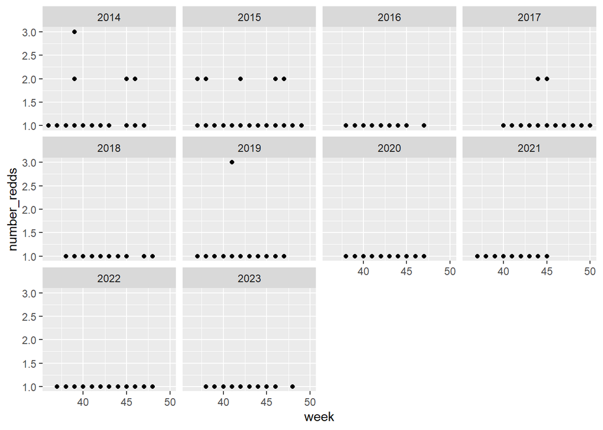

### Data exploration by year - the goal is to compare to Chris documntation

Summarizing by date and survey location

```
## Rows: 36,864
## Columns: 3
## Groups: location, date [1,539]
## $ location     <chr> "aleck", "aleck", "aleck", "aleck", "aleck", "aleck", "al…
## $ date         <date> 2017-11-09, 2017-11-09, 2017-11-09, 2017-11-22, 2017-11-…
## $ number_redds <int> 1, 1, 1, 1, 1, 1, 1, 1, 1, 1, 1, 1, 1, 1, 1, 1, 1, 1, 1, …
```

```
## $by_date
## # A tibble: 15,759 × 3
##    location date       total_redds
##    <chr>    <date>           <int>
##  1 aleck    2014-09-09           0
##  2 aleck    2014-09-15           0
##  3 aleck    2014-09-18           0
##  4 aleck    2014-09-22           0
##  5 aleck    2014-09-25           0
##  6 aleck    2014-09-26           0
##  7 aleck    2014-09-29           0
##  8 aleck    2014-10-01           0
##  9 aleck    2014-10-02           0
## 10 aleck    2014-10-03           0
## # ℹ 15,749 more rows
##
## $by_year_week
## # A tibble: 7,650 × 4
##    location  year  week total_redds
##    <chr>    <dbl> <dbl>       <int>
##  1 aleck     2014    36           0
##  2 aleck     2014    37           0
##  3 aleck     2014    38           0
##  4 aleck     2014    39           0
##  5 aleck     2014    40           0
##  6 aleck     2014    41           0
##  7 aleck     2014    42           0
##  8 aleck     2014    43           0
##  9 aleck     2014    44           0
## 10 aleck     2014    45           0
## # ℹ 7,640 more rows
```